# Final Project 516 - Re-do

Zoe Aiello

1/29/2023

# Introduction

The purpose of this report is to investigate the health of US high school students by analyzing BMI, exercise, and sleep data collected from US high school students in 2017 and 2007. We will answer two questions of interest:

1. Are high schoolers getting more overweight?
2. After accounting for differences in age and sex, is BMI associated with year?

**Data Exploration**

The population distribution of the BMI of high school students in the US in 2017 appears to be skewed to the right with a mean of 23.62 and a standard deviation of 5.20. The population has a 25th percentile of 20.09 and a median of 22.44. The population distribution of the BMI of high school students in the US in 2007 appears to be skewed to the right with a mean of 23.78 and a standard deviation of 4.95. The population median is 22.58. The difference in median BMIs for the two populations is -0.1333 where BMIs in 2007 were 0.1333 points higher than in 2017.

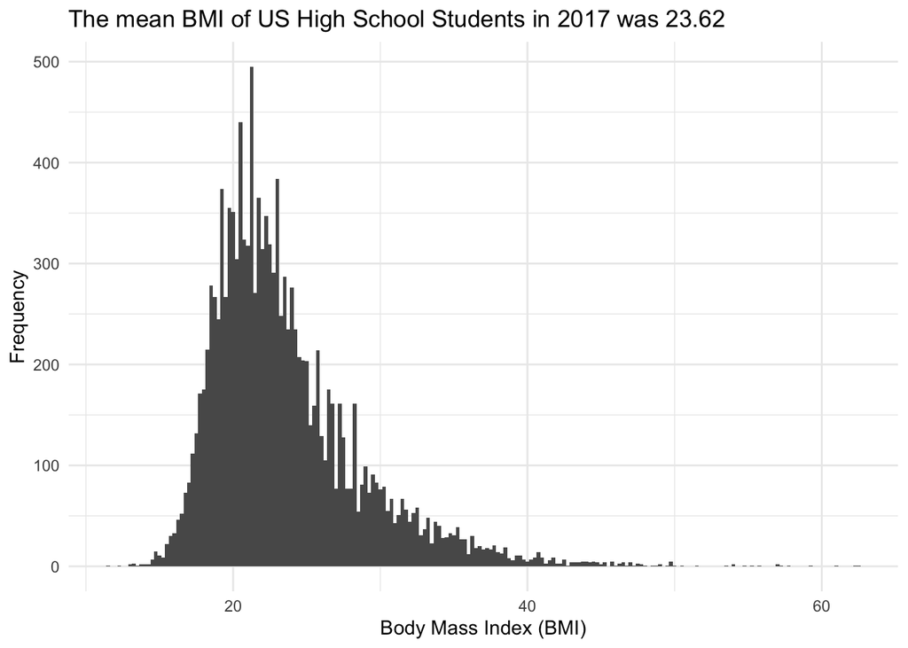

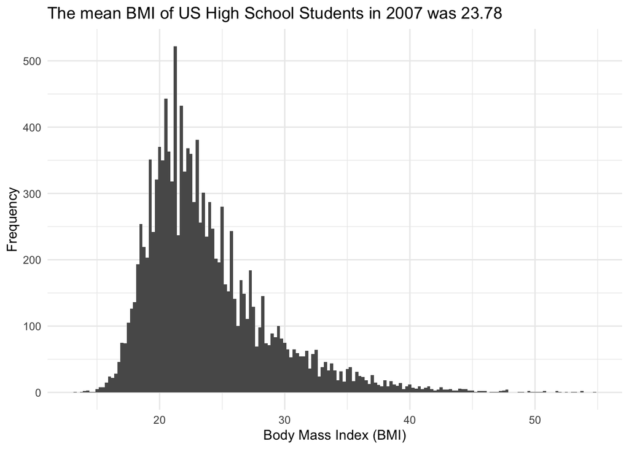

# Methods

The Youth Risk Behavior Surveillance System (YRBSS) is a survey conducted by the CDC in US states and territories. As of 2011, 92% of states, 96% of large urban school districts, 100% of territories, and 100% of tribal governments participate in the Youth Risk Surveillance System. The survey includes questions that assess risky behavior in students from drug and alcohol use, sex and contraceptive use, health behaviors (exercise and sleep), to general demographic information.

To answer our two questions of interest we will deploy a Welches two-sample t-test and a multiple linear regression model.

**Welch’s two-sample t-test**

A Welch’s two sample t-test is used to test the hypothesis that our two samples have equal means.

The hypotheses are as follows:

$H_o$: $\mu_1$ - $\mu_2$ = 0

$H_1$: $\mu_1$ - $\mu_2$ > 0

where $\mu_1$ is the mean BMI of US high school students in 2007, and $\mu_2$ is the mean BMI of US high school students in 2017.

$H_o$: The difference in the mean BMI of US high school students in 2007 and 2017 is equal to 0.

$H_1$: The difference in the mean BMI of US high school students in 2007 and 2017 is greater than to 0.

The Welch’s two-sample t-test has two assumptions:

1. Independence
2. Normality

**Multiple linear regression model**

The multiple linear regression model estimates the relationship between one quantitative response variable and multiple explanatory variables.

The multiple linear regression model we will use is as follows:
$$\mu(BMI|age,sex,year) = \beta_0 + \beta_1age +
\beta_2sex + \beta_3year$$
where $\mu(BMI|age,sex,year)$ is the mean BMI of US high school students given their age, sex, and the year of the survey. $\beta_0$ is the intercept term, $\beta_1$ is the coefficient of the students age, $\beta_2$ is the coefficient of the students sex, and $\beta_3$ is the coefficient of the year that the survey was conducted.

The hypotheses are as follows:

$H_o$: $\beta_3$ = 0

$H_1$: $\beta_3 \neq$ 0

$H_o$: After accounting for differences in age and sex, year is not associated wit BMI (AKA the coefficient of year is 0.

$H_1$: After accounting for differences in age and sex, year is associated with BMI (AKA the coefficient of year is not 0).

The multiple linear regression model has four assumptions:

1. The model is specified correctly: the mean of Y actually is a linear function.
2. Independence
3. Constant Variance
4. Normality

A justification for the assumptions are included in the Appendix.

# Results

**Are high-schoolers getting more overweight?**

To assess the claim that high-schoolers are getting more overweight, we will conduct a hypothesis test for the difference in the mean BMIs of high school students in 2007 vs. 2017.

We will use the Welch’s two-sample t-test which assumes that the variances are unequal. We have verified that our samples are independent, and that they’re normal (given CLT) (see Appendix).

```
##
##  Welch Two Sample t-test
##
## data:  yrbss_2007$bmi and yrbss_2017$bmi
## t = 2.4775, df = 26125, p-value = 0.006619
## alternative hypothesis: true difference in means is greater than 0
## 95 percent confidence interval:
##  0.05227978        Inf
## sample estimates:
## mean of x mean of y
##  23.77572  23.62015
```

The mean BMI of US high school students in 2007 was 23.78 and the mean BMI of US high school students in 2017 was 23.62. There is enough evidence to reject the null hypothesis that there is no difference in the mean BMI of US high school students in 2017 vs. in 2007 (alpha = 0.05, p = 0.0067). However, the mean BMI in 2007 is higher than the mean BMI of 2017. So, to answer our initial question: high school students are not becoming more overweight.

**After accounting for differences in age and sex is BMI associated with year?**

```
##
## Call:
## lm(formula = bmi ~ age + sex + year, data = yrbss)
##
## Residuals:
##     Min      1Q  Median      3Q     Max
## -11.080  -3.392  -1.203   2.164  40.099
##
## Coefficients:
##              Estimate Std. Error t value Pr(>|t|)
## (Intercept) 26.670496  12.580387   2.120    0.034 *
## age          0.554548   0.025331  21.892  < 2e-16 ***
## sex         -0.289794   0.062249  -4.655 3.25e-06 ***
## year        -0.005832   0.006236  -0.935    0.350
## ---
## Signif. codes:  0 '***' 0.001 '**' 0.01 '*' 0.05 '.' 0.1 ' ' 1
##
## Residual standard error: 5.032 on 26164 degrees of freedom
## Multiple R-squared:  0.01925,    Adjusted R-squared:  0.01913
## F-statistic: 171.2 on 3 and 26164 DF,  p-value: < 2.2e-16
```

# Discussion

The purpose of this report was to investigate the health of US high school students in 2017 and 2007. We answered two questions of interest:

**1. Are high schoolers getting more overweight?** We found that high schoolers are not getting more overweight over time. However, there are some limitations to this conclusion. In this report, only the 2007 and 2017 data were compared. 2007 or 2017 could have been outlying years and it’s impossible to make a reliable conclusion with such a small sample size (n=2 years). Therefore, to better answer this question it may be useful to construct a time series analysis using all the BMI data from 1991 through 2017.

**2. After accounting for differences in age and sex, is BMI associated with year?** We found that BMI was not associated with year after accounting for age and sex. This analysis has similar limitations to the previous analysis, however. If we were to construct the same model using all the YRBSS data from 1991 through 2007, we may come up with a different conclusion. Additionally, it may be difficult to analyze all of the data from 1991 through 2017 because different questions were asked throughout the years, different methods were used and different states, territories and school districts participated. If we were to conduct a future analysis with all of this data, additional limitations would be present.

# Appendix

**Independence and Scope of Inference Assessment**

First, let’s look at the data collection procedures for the Youth Risk Behavioral Surveillance System to determine if the data are independent and representative. Reading from the CDC’s Methodology of the Youth Risk Behavior Surveillance System - 2013 document, we can learn about the collection procedures for our data. The surveys may suffer from non-response bias, however, the response rates appear to be very high (overall, <60%) and students who are absent on the day of the survey are allowed to complete the survey at a later time which increases the response rate and allows for better representation. Parents are required to allow their students to opt-in to the survey in 10% of schools, and in 90% of schools, only passive permission was required (requiring parents to ‘opt-out’ if they did not want their student to participate). This could introduce some bias to the data since the data collection procedures were not consistent across school districts, but the opt-out procedure was used in the vast majority of cases and this procedure would allow for many more students to participate. There is an overall participation of 93% which suggests that the data are fairly representative. As with any survey, response bias may be present. Students may want to respond with socially-desirable answers. However, the survey conductors attempt to mitigate this bias by allowing students to respond anonymously, spreading students across the classroom and encouraging them to use an additional sheet of paper to cover their answers as they go. For our purposes, we can assume that the data are independent and representative of the population of high school students in the US. Learn more about the YRBSS Methodology here: https://www.cdc.gov/healthyyouth/data/yrbs/pdf/2017/2017_yrbs_sadc_documentation.pdf

**Normality Assessment**

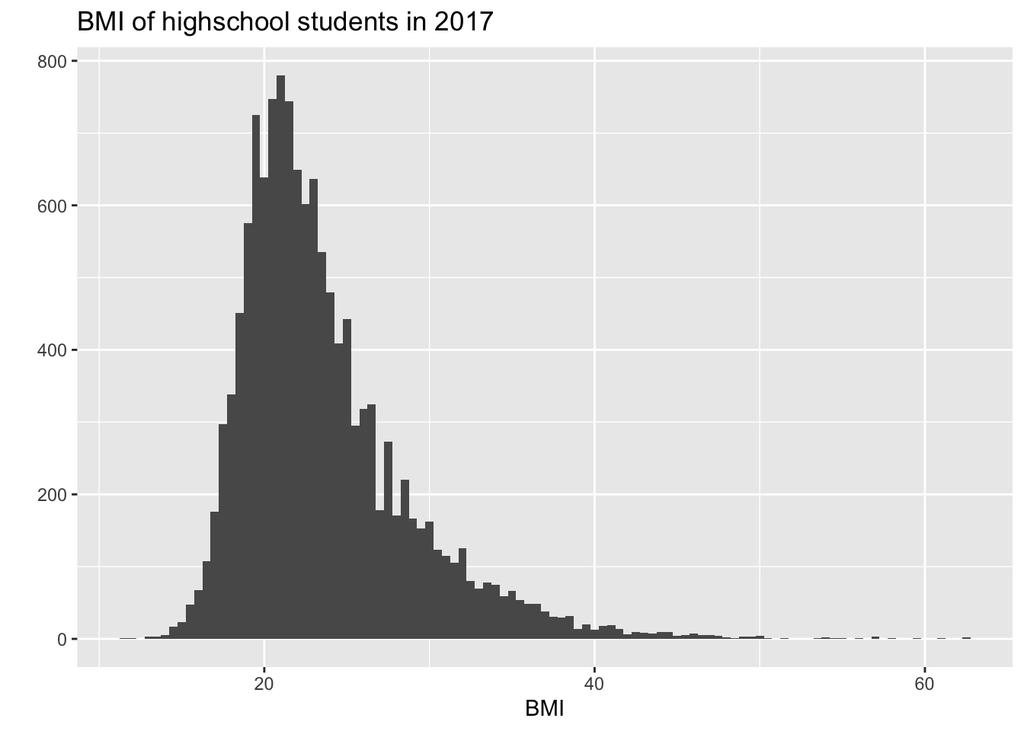

[figure not shown]

**Homogeneity of Variances** We will use the Levene’s test to test for homogeneity of variances. Since the data appear to be slightly skewed to the right, we will use the median in our test (see population distribution plots).

Ho: $\sigma^2_1$ = $\sigma^2_2$ Ha: $\sigma^2_1$ =/= $\sigma^2_2$

```
## Levene's Test for Homogeneity of Variance (center = median)
##          Df F value    Pr(>F)
## group     1  11.838 0.0005814 ***
##       26166
## ---
## Signif. codes:  0 '***' 0.001 '**' 0.01 '*' 0.05 '.' 0.1 ' ' 1
```

With an F-value of 11.8 and a p-value of 0.0005, we reject the null hypothesis that the variances of the BMI of high school students in 2007 and 2017 are equal at the 5% significance level.

```r
knitr::opts_chunk$set(echo = TRUE)
library(ggplot2)
library(car)
library(dplyr)
library(tidyverse)
library(broom)

# read in data
yrbss_2007 <- readRDS("yrbss_2007.rds")
yrbss_2017 <- readRDS("yrbss_2017.rds")


#### Data Exploration ####
# mean bmi 2017
mean_2017 <- mean(yrbss_2017$bmi)

# sd of BMI 2017
sd_2017 <- sd(yrbss_2017$bmi)

# mean bmi 2007
mean_2007 <- mean(yrbss_2007$bmi)

# sd of BMI 2007
sd_2007 <- sd(yrbss_2007$bmi)

# calculate the difference in median BMI 2007 v. 2017
dif_meds <- median(yrbss_2017$bmi) - median(yrbss_2007$bmi)

# plot of 2017 BMI
ggplot(aes(x = bmi), data = yrbss_2017) +
  geom_histogram(binwidth = 0.25) +
  theme_minimal() +
  xlab("Body Mass Index (BMI)") +
  ylab("Frequency") +
  ggtitle("The mean BMI of US High School Students in 2017 was 23.62")

# plot of 2007 BMI
ggplot(aes(x = bmi), data = yrbss_2007) +
  geom_histogram(binwidth = 0.25) +
  theme_minimal() +
  xlab("Body Mass Index (BMI)") +
  ylab("Frequency") +
  ggtitle("The mean BMI of US High School Students in 2007 was 23.78")


# t-test
yrbss.t <- t.test(yrbss_2007$bmi, yrbss_2017$bmi, alternative = "greater")
yrbss.t


#### Data Wrangling ####
# convert tibbles into dfs
df_2007 <- as.data.frame(yrbss_2007)
df_2017 <- as.data.frame(yrbss_2017)

# combine the dfs
yrbss <- rbind(df_2017, df_2007)

# change variable names to be more recognizable
colnames(yrbss)[7:11] <- c("rode.w.drunk.driver", "smoke", "milk", "sleep", "exercise")

# create dummy variables
# age
yrbss$age <- ifelse(
  yrbss$age ==
    "12 years old or younger",
  12,
  ifelse(yrbss$age ==
           "13 years old",
         13,
         ifelse(yrbss$age ==
                  "14 years old",
                14,
                ifelse(yrbss$age ==
                         "15 years old",
                       15,
                       ifelse(yrbss$age ==
                                "16 years old",
                              16,
                              ifelse(yrbss$age ==
                                       "17 years old",
                                     17,
                                     ifelse(yrbss$age ==
                                              "18 years old or older",
                                            18, 0)))))))

# sex
yrbss$sex <- ifelse(yrbss$sex == "Female", 1, 0)


 #### Evaluate the Pattern of missingness ####
# https://jenslaufer.com/data/analysis/visualize_missing_values_with_ggplot.html

# don't show warnings for summarise
options(dplyr.summarise.inform = FALSE)

suppressWarnings(missing.values <- yrbss %>%
  gather(key = "key", value = "val") %>%
  mutate(isna = is.na(val)) %>%
  group_by(key) %>%
  mutate(total = n()) %>%
  group_by(key, total, isna) %>%
  summarise(num.isna = n()) %>%
  mutate(pct = num.isna / total * 100))

suppressWarnings(levels <- (missing.values  %>%
                              filter(isna == T) %>% arrange(desc(pct)))$key)

suppressWarnings(row.plot <- yrbss %>%
  mutate(id = year) %>%
  gather(-id, key = "key", value = "val") %>%
  mutate(isna = is.na(val)) %>%
  ggplot(aes(key, id, fill = isna)) +
    geom_raster(alpha=0.8) +
    scale_fill_manual(name = "",
        values = c('steelblue', 'tomato3'),
        labels = c("Present", "Missing")) +
    scale_x_discrete(limits = levels) +
    labs(x = "Variable",
           y = "Year", title = "Missing values by year") +
    coord_flip())

suppressWarnings(print(row.plot))


##### Evaluate the correlation between the variables ####
suppressWarnings(cor(yrbss[1:4]))

# According to the correlation matrix, none of the variables are significantly
# correlated with each other. BMI and age have the highest correlation
# coefficient but if we consider 0.25 to be the cutoff for a weak correlation
# then BMI and age do not come close to reaching the threshold.


#### Residual Diagnostics ####
# Check the assumptions of the multiple linear regression model

# fit a regression model
suppressWarnings(model <- lm(bmi ~ age + sex + year, data = yrbss))

# augment
suppressWarnings(mod_aug <- augment(model, yrbss))

# fitted v. residual plot
suppressWarnings(qplot(.fitted, .resid, data = mod_aug))

# residual v. explanatory variable plots
suppressWarnings(qplot(sex, .resid, data = mod_aug))

suppressWarnings(qplot(age, .resid, data = mod_aug))

suppressWarnings(qplot(year, .resid, data = mod_aug))

# Assumptions:
# 1. Normality - In the .resid vs. .fitted plot, there appears to be a
# violation of the normality assumption since most values are situated
# above the 0 line, indicating a skew to the right. This violation is not of
# much concern since the sample size is large.

# 2. Constant Variance - There may be non-constant variance in the age v.
# resid plot, but this can probably be explained by less observations for
# younger students.

# 3. Independence - See a discussion of independence and scope of inference in
# the appendix. We can assume that the data are independent and representative
# of the population of US high school students.

summary(model)
#length(yrbss_2017$bmi)
#length(yrbss_2007$bmi)

norm_2017_plt <- qplot(yrbss_2017$bmi, binwidth = 0.5) + labs(
    title = "BMI of highschool students in 2017",
    x = "BMI"
  )

suppressWarnings(print(norm_2017_plt))

norm_2007_plt <- qplot(yrbss_2007$bmi, binwidth = 0.5) + labs(
    title = "BMI of highschool students in 2007",
    x = "BMI"
  )

suppressWarnings(print(norm_2017_plt))
bmi_2017 <- as.vector(unlist(yrbss_2017$bmi)) # Converting both BMI columns
# into vectors
bmi_2007 <- as.vector(unlist(yrbss_2007$bmi))
bmi.data = stack(list(bmi_2007=bmi_2007, bmi_2017=bmi_2017)) # Stacking the
# vectors
leveneTest(values~ind, bmi.data) # Performing the Levene's test with the medians
```

[output not shown]